# Fare-Capping Mixed Logit Model

Nikhil Kalathil

4/16/2020

We start we data in three dimensions: household, person, and trip. We begin our analysis by considering the mode choice decision of people who take more than 2 public transit trips on their third trip.

First, we create a broad mode decision variable.

Numbering scheme for the behavioral model:

```r
trips <- trips %>%
  mutate(transit = as.factor(case_when(
    mode %in% c(7,8,9,10) ~ "transit",
    mode %in% c(1,3) ~ "private drive",
    mode %in% c(2,6) ~ "private ride",
    mode %in% c(5) ~ "bike",
    mode %in% c(4) ~ "walk",
    mode %in% c(6) ~ "plane",
    mode %in% c(12) ~ "other"
  )))
```

Let us take a preview of how many observations we have here.

```r
trips %>%
  filter(!is.na(transit)) %>%
  group_by(transit) %>%
  summarise(weights = sum(WDTRIPWGT11, na.rm = TRUE), count = n()) %>%
  arrange(-weights)
```

```
## # A tibble: 6 x 3
##   transit        weights count
##   <fct>            <dbl> <int>
## 1 private drive 4780156. 64094
## 2 private ride  2204394. 31974
## 3 walk          1576401. 15874
## 4 transit        667927.  5667
## 5 bike            97107.  1363
## 6 other            6034.   103
```

The vast majority of our observations are in the physical and private transportation categories. It is interesting to note the prevalance of the physical transportation category.

We are now interested in looking at the sub-population that takes more than two trips. Our data is organized so that each row is a unique leg of a trip. Each trip is tied to a person’s travel diary entry. We must first identify how many people took two or more trips. By definition, anyone who had a trip with more than stages takes more than 2 trips.

Thus, we must identify the individuals who took multiple one stage trips.

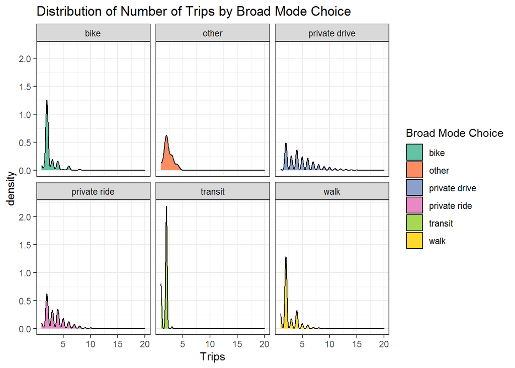

```r
trips %>%
  filter(TRIPSTAGES <= 2, !is.na(transit)) %>%
  group_by(PERSID, transit) %>%
  summarise(weight = sum(WDTRIPWGT11, na.rm = TRUE), n = n()) %>%
  ggplot() +
  geom_density(aes(n, fill = transit, weight = weight), position = "identity") +
  facet_wrap(~transit) +
  scale_fill_brewer(palette = "Set2") +
  labs(title = "Distribution of Number of Trips by Broad Mode Choice", fill = "Broad Mode Choice", x = "Trips") +
  theme_bw()
```

Now, how many of these people took more than 2 one stage trips?

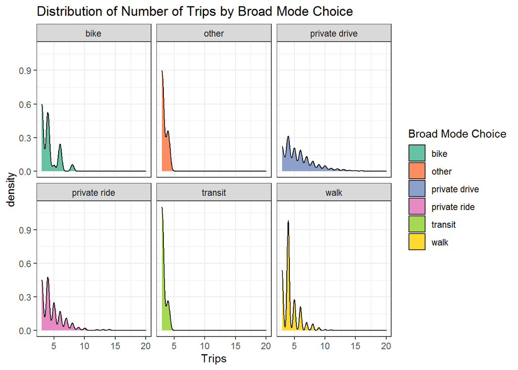

```r
trips %>%
  filter(TRIPSTAGES <= 2, !is.na(transit)) %>%
  group_by(PERSID, transit) %>%
  summarise(weight = sum(WDTRIPWGT11, na.rm = TRUE), n = n()) %>%
  filter(n > 2) %>%
  ggplot() +
  geom_density(aes(n, fill = transit, weight = weight), position = "identity") +
  facet_wrap(~transit) +
  scale_fill_brewer(palette = "Set2") +
  labs(title = "Distribution of Number of Trips by Broad Mode Choice", fill = "Broad Mode Choice", x = "Trips") +
  theme_bw()
```

```r
trips_2 <- trips %>%
  filter(!is.na(transit)) %>%
  group_by(PERSID) %>%
  count() %>%
  rename(total_trips = n) %>%
  left_join(trips) %>%
  mutate(trip_seq = row_number())
```

We now have a variable telling us how many trips people in our data took. We also have a variable indexing a trip. The specific population we will begin our analysis on is individuals who took more than two total trips. Our first model will atempt to estimate the factors that influence their mode choice for the their third trip.

```r
trips_freq <- trips_2 %>%
  filter(total_trips > 2 | TRIPSTAGES > 2)
```

Among these people, let us examine how many observations in each broad mode choice category we have.

```r
trips_freq %>%
  filter(!is.na(transit)) %>%
  group_by(transit) %>%
  summarise(weights = sum(WDTRIPWGT11, na.rm = TRUE), count = n()) %>%
  arrange(-weights)
```

```
## # A tibble: 6 x 3
##   transit        weights count
##   <fct>            <dbl> <int>
## 1 private drive 3808541. 51176
## 2 private ride  1669967. 24043
## 3 walk          1413741. 13852
## 4 transit        664956.  5628
## 5 bike            58348.   879
## 6 other            5198.    87
```

It is interesting to note that most people in our dataset took more than 2 trips. How can we identify the mode choice of the third or later trips?

```r
trips_freq %>%
  filter(leg > 2 | (total_trips > 2 & leg == 1)) %>%
  filter(!is.na(transit)) %>%
  group_by(transit) %>%
  summarise(weights = sum(WDTRIPWGT11, na.rm = TRUE), count = n()) %>%
  arrange(-weights)
```

```
## # A tibble: 6 x 3
##   transit        weights count
##   <fct>            <dbl> <int>
## 1 private drive 3784510. 50841
## 2 private ride  1659779. 23917
## 3 walk          1368006. 13329
## 4 transit        148518.  1330
## 5 bike            57773.   870
## 6 other            5172.    86
```

We can now ask a question: does we see an observable difference in mode choice between the whole population and this population?

```r
brisbane_total_trips = as.numeric(trips_freq %>%
  ungroup() %>%
  filter(!is.na(transit)) %>%
  summarise(count = n()))
```

```r
trips_one <- trips_2 %>%
  filter(!is.na(transit), total_trips <= 2) %>%
  group_by(transit) %>%
  summarise(weights = sum(WDTRIPWGT11, na.rm = TRUE), count = n()) %>%
  mutate(percent_trips = count/brisbane_total_trips, level = "One or Two Trips")
```

```r
trips_freq %>%
  filter(leg > 2 | (total_trips > 2 & leg == 1)) %>%
  filter(!is.na(transit)) %>%
  group_by(transit) %>%
  summarise(weights = sum(WDTRIPWGT11, na.rm = TRUE), count = n()) %>%
  mutate(third_percent_trips = count/brisbane_total_trips, level = "Third or Later") %>%
  select(transit, third_percent_trips) %>%
  left_join(trips_one, . ) %>%
  select(transit, percent_trips_12 = percent_trips, percent_trips_3plus = third_percent_trips) %>%
  mutate(percent_trips_12 = round(100*percent_trips_12,2), percent_trips_3plus = round(100*percent_trips_3plus,2))
```

```
## # A tibble: 6 x 3
##   transit       percent_trips_12 percent_trips_3plus
##   <fct>                    <dbl>               <dbl>
## 1 bike                      0.51                0.91
## 2 other                     0.02                0.09
## 3 private drive            13.5                53.1
## 4 private ride              8.29               25
## 5 transit                   0.04                1.39
## 6 walk                      2.11               13.9
```

We can see that there seems to be an apparent difference in mode decisions between the first two legs of a trip that a person takes and the third or later leg of that trip.

As a reminder, our goal is to estimate if the introduction of fare capping increases the probability that an individual either 1) takes a third ride that they otherwise wouldn’t; or, 2) chooses public transportation as their third ride.

We now turn to multinomial logit models to estimate the mode choice decision. We estimate models in the following order:

1. The only thing that matters is what leg of the trip you are on, the total number of stages in your trip, the number of total trips that you make, the duration of the trip, and your trip distance.
2. Introduce departure time and trip purpose variables.
3. Introduce household level variables such as fare, year, weekend, car ownership, bike ownership, and HHIC
4. Introduce person level variables such as age, gender, avialability, work status, student status

Whenever possible, in each stage, we estimate a basic multinomial logit model as well as a mixed logit model.

It is important to note that in our model, we treat an individual activity based decision as dependent on a trip level perspective of transportation choices.